# A5: Incarceration

### Introduction

The data set I have chosen to use is the us.prison-jail-rates.csv. Specifically I will be looking at the prison rates for the total population variables, focusing on the Latinx, Black, and White population and how geographical location affects the prisoner’s rate while also remaining consistent with the racial inequalities shown within the legal system, favoring white individuals over BIPOC citizens.

I have chosen to focus on the Latinx, Black, and white population due to the inequalities highlighted in the documentary “13th”, within the documentary the explanation of racial discrimination across America varies in severity in the legal system depending on the geographical location. As a result I aim to strive to show the consistency in racial discrimination across and the numerous geographical boundaries associated with incarceration rate.

### Summary Information

- What is the average value of black_prison_pop_rate, white_prison_pop_rate, latine_prison_pop_rate across all the counties in CA (in 2015)?
- What is black_prison_pop_rate the highest in CA in 1995 and 2015?
- What is black_prison_pop_rate the lowest in CA in 1995 and 2015?
- Which urbanicities had the highest rate of latinx and black prisoners rate in CA in 2015?
- Which urbanicities and state had the highest rate of latinx and black prisoners rate the US in 2015?

```
## [1] "What is the average value of black_prison_pop_rate, white_prison_pop_rate, latine_prison_pop_rate across all the counties in CA (in 2015)?"
```

```
## [1] 2011.373
```

```
## [1] 478.1244
```

```
## [1] 391.7184
```

```
## [1] "What is black_prison_pop_rate the highest in CA in 1995 and 2015?"
```

```
## [1] "1995"
```

```
## [1] 13888.89
```

```
## [1] "2015"
```

```
## [1] 4376.11
```

```
## [1] "What is black_prison_pop_rate the lowest in CA in 1995 and 2015?"
```

```
## [1] "1995"
```

```
## [1] 435.59
```

```
## [1] "2015"
```

```
## [1] 894.23
```

```
## [1] "Which urbanicities had the highest rate of latinx and black prisoners rate in CA in 2015?"
```

```
##   urbanicity
## 1  small/mid
```

```
##   urbanicity
## 1  small/mid
```

```
## [1] "Which urbanicities and state had the highest rate of latinx and black prisoners rate the US in 2015?"
```

```
##   state
## 1    NC
```

```
##   state
## 1    NE
```

### The Dataset

Who collected the data?

Vera: Institute of Justice organization. Specifically, Oliver Hinds, Olive Lu, James Wallace-Lee, and Jacob Kang-Brown.

How was the data collected or generated?

The data was collected from multiple sources. The sources include the National Corrections Reporting Program (NCRP). The data also includes data from the U.S. Census Bureau and the Centers for Disease Control and Prevention, the U.S. Department of Agriculture, and the U.S. census Bureau. Data was also collected with information from the Annual Survey of Jails (ASJ), Census of Jails, and the Death in Custody Reporting Program (DCRP). The final four data sources are used to estimate population and geographical information for the data set.

Why was the data collected?

The data was originally collected to show the difference between state and county decision making on incarcerations rather than a united entity. The data further analysis racial trends within the incarceration data and how they vary based on county rather than state.

How many observations (rows) are in your data?

```r
prison_rate <- read.csv("us-prison-jail-rates.csv")
nrow(prison_rate)
```

```
## [1] 153811
```

How many features (columns) are in the data?

```r
ncol(prison_rate)
```

```
## [1] 23
```

What, if any, ethical questions or questions of power do you need to consider when working with this data?

A question of power I need to consider when working with the data is the large age range being evaluated for prisoners. The prisoners rate being evaluated are between the ages of 15-64. Fifteen year olds are legally considered a minor. By having such a large age range between prisoners seems irrelevant for the data as it looks at the total population of prisoners and race demographic. However, as depicted in the documentary “13th” Black youth are depicted as adults due to racial discrimination. As a result by limiting the data to a singular age range connects youth with adults.

What are possible limitations or problems with this data? (at least 200 words)

Possible limitations associated with the data include missing variables based on year and county. Many of the variables throughout the dataset are labeled ‘NA’. In previous readings the incorporation of NA variables can lead to misinterpretation of the data as a whole. The NA data is due to lack of public information, sully concerning the older dates pre 1990s; however, there were a few dates post 2010s that included missing data. This may be due to a number of reasons such as age of data and size of the county. For example in my summary I include the overall average rate change between all County and State data for Latinx, White and Black prisoners. However, I needed to exclude data including NA to obtain the mean of each racial demographic. My research is greatly based on the filtering of the data I had to go through in order to find a County, Year, State that coincides with the Latinx, White, and Black prisoner rate. Another limitation from the data is the lack of immediate legend describing the rate change of the data. The codex offered alongside the data requires pages of reading to fully interpret the data set. However, extensive reading can pose accessibility issues for people attempting to explore the data. The codex should include a table and quick explanations to the data being presented as an effective overview of the data collected.

### Trends Over Time Chart

[figure not shown]

### Variable Comparison Chart

The second graph depicts the Top 10 Most Populated CA Prisons by County (Black Prisoner Rate) in 2015. here I explore population and rate between Black prisoner rate and total population rate in County prison population. A pattern from the data is the larger most densely populated county (Los Angeles) remain consistent with the high rates of incarcerated Black prisoners remaining high with the previous trend line.

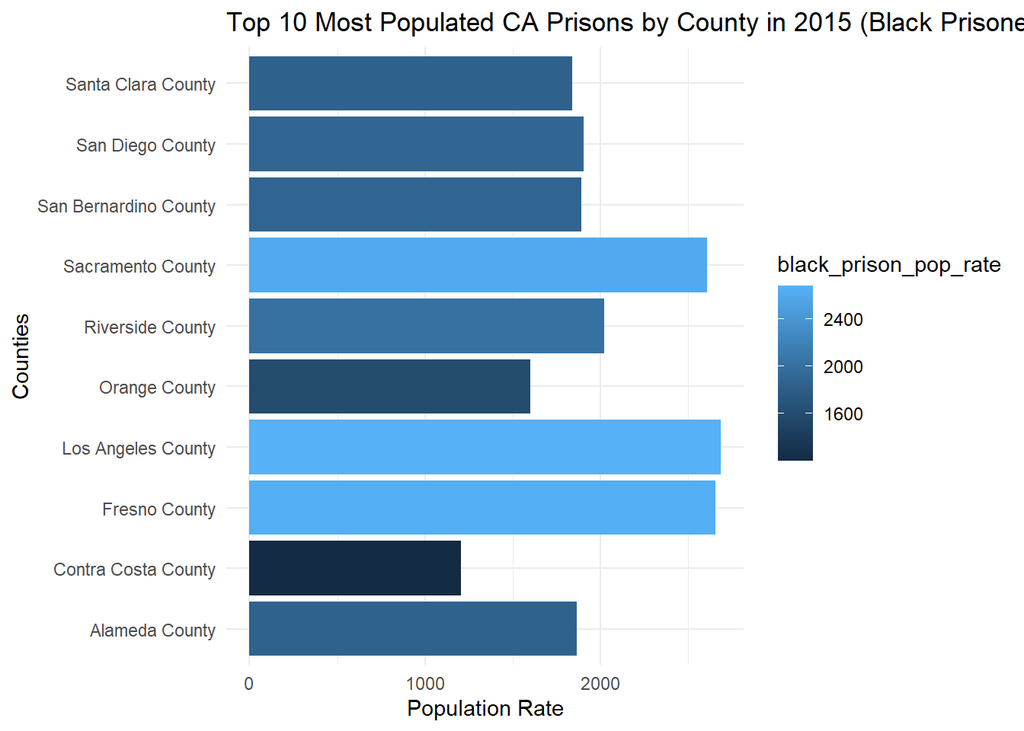

### Map

Rather than a pattern I found an inconsistency within my data. The three counties with the highest prison rate of Black prisoners in 2015 where Tehama County (rural), Lake County (rural), Shasta County (small/mid), as depicted by the red dots. The largest rate of change occurred in rural and small/mid. Due to this inconsistency I further investigated the possible reasoning behind the outcome and came upon the electoral results from the 2020 election. Tehama and Shasta are considered conservative counties with the state of California. Due to this revelation the highest prison rate of Black prisoners in 2015 remains consistent within the lengths of geographical location based on political association rather than population.

link: https://www.kcra.com/article/california-election-results-2020-county-map/34922105

[output not shown]

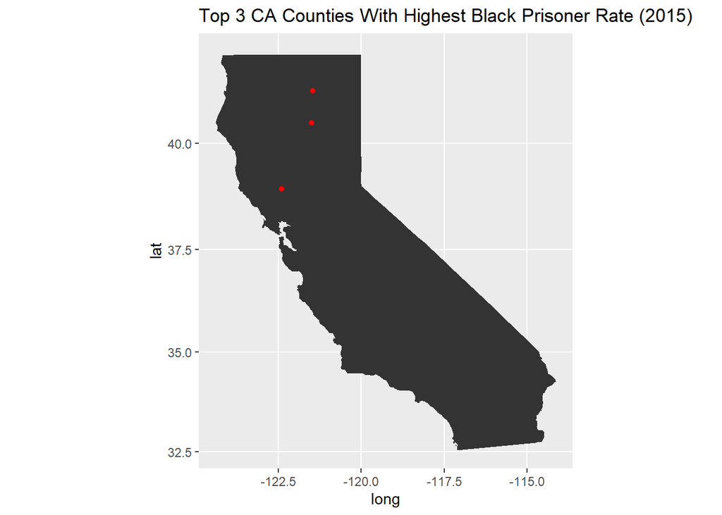